# Stack Overflow Programming Language Trends Analysis

Munem Shahriar Shams

#Loading Libraries

```r
library(readr)
library(dplyr)
```

```r
library(ggplot2)
library(scales)
```

#Loading the dataset

```r
data <- read_csv("stack_overflow_data.csv")
head(data)
```

```
## # A tibble: 6 × 4
##    year tag             num_questions year_total
##   <dbl> <chr>                   <dbl>      <dbl>
## 1  2008 treeview                   69     168541
## 2  2008 scheduled-tasks            30     168541
## 3  2008 specifications             21     168541
## 4  2008 rendering                  35     168541
## 5  2008 http-post                   6     168541
## 6  2008 static-assert               1     168541
```

# Data Preparation

To compare languages across years, we calculate the percentage of total questions associated with each tag. This allows us to measure relative popularity rather than raw counts.

```r
data_percentage <- data %>%
  mutate(
    percentage = (num_questions / year_total) * 100
  )
```

# Trend Analysis: R Programming Language

We first examine how the popularity of the **R programming language** has evolved over time.

```r
r_over_time <- data_percentage %>%
  filter(tag == "r")
```

## Visualization: R Popularity Over Time

The following chart shows how the percentage of Stack Overflow questions tagged with **R** has changed over time.

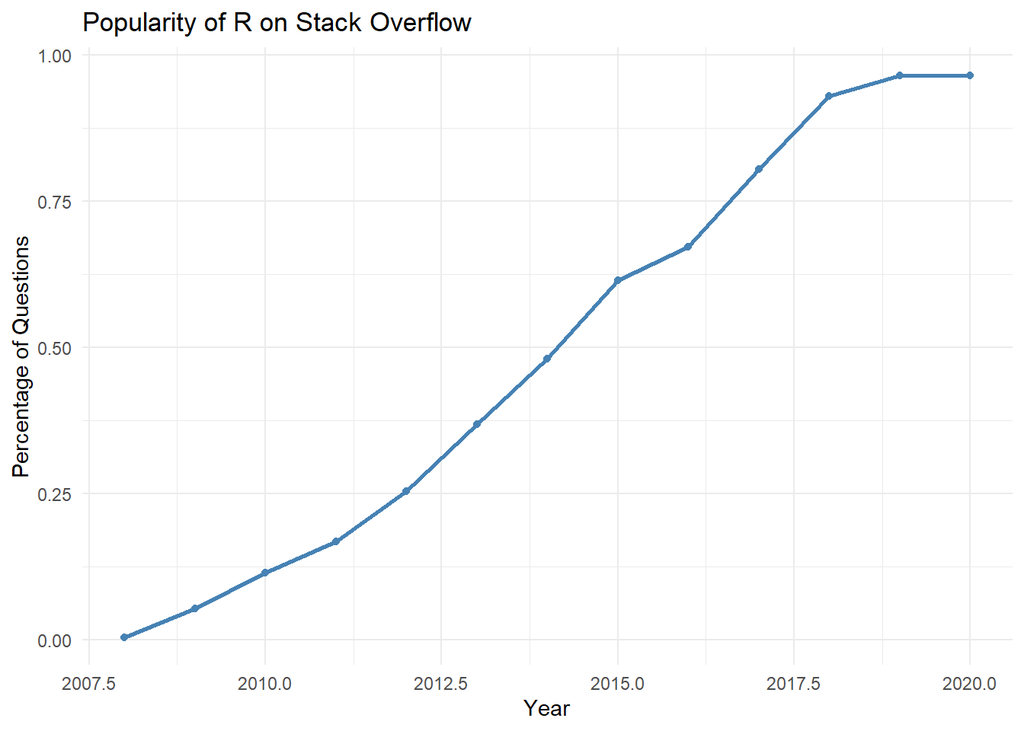

```r
ggplot(r_over_time, aes(x = year, y = percentage)) +
  geom_line(color = "steelblue", linewidth = 1) +
  geom_point(color = "steelblue") +
  labs(
    title = "Popularity of R on Stack Overflow",
    x = "Year",
    y = "Percentage of Questions"
  ) +
  theme_minimal()
```

# R Popularity in 2020

Next we extract the statistics for the year 2020 to determine the share of Stack Overflow questions related to R.

```r
r_2020 <- r_over_time %>%
  filter(year == 2020)

r_2020
```

```
## # A tibble: 1 × 5
##    year tag   num_questions year_total percentage
##   <dbl> <chr>         <dbl>      <dbl>      <dbl>
## 1  2020 r             52662    5452545      0.966
```

# Identify Most Popular Programming Languages

Next we determine which programming languages received the highest number of questions between 2015 and 2020.

```r
sorted_tags <- data %>%
  filter(year >= 2015 & year <= 2020) %>%
  group_by(tag) %>%
  summarise(tag_total = sum(num_questions), .groups = "drop") %>%
  arrange(desc(tag_total))
```

```r
highest_tags <- sorted_tags %>%
  slice_head(n = 5)

highest_tags
```

```
## # A tibble: 5 × 2
##   tag        tag_total
##   <chr>          <dbl>
## 1 javascript   1373634
## 2 python       1187838
## 3 java          982747
## 4 android       737330
## 5 c#            730045
```

# Visualization: Popular Programming Languages

Finally, we visualize how the most popular programming languages have evolved over time.

```r
top_tags <- highest_tags$tag

data_subset <- data_percentage %>%
  filter(tag %in% top_tags, year >= 2015)
```

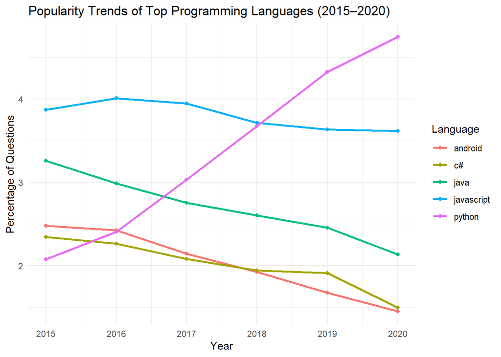

```r
ggplot(data_subset, aes(x = year, y = percentage, color = tag)) +
  geom_line(linewidth = 1) +
  geom_point() +
  labs(
    title = "Popularity Trends of Top Programming Languages (2015–2020)",
    x = "Year",
    y = "Percentage of Questions",
    color = "Language"
  ) +
  theme_minimal()
```

# Key Insights

Several insights emerge from this analysis:

- Stack Overflow question data provides a strong indicator of developer interest in programming languages.
- R shows steady growth due to its importance in data science and analytics.
- A small group of programming languages dominates most Stack Overflow discussions.
- Observing trends over time helps identify emerging technologies and declining tools.

# Conclusion

Stack Overflow question data offers a valuable perspective on programming language popularity. By analyzing tagged questions over time, we can observe how developer interest evolves across technologies.

These insights can help developers and organizations decide which programming languages to focus on learning and adopting.